# Project Improvement

Lukasz Marchel, Sebastian Kremer

5/2/2021

```css
.colorCode {
background-color: lightgreen;
}
```

## Problem Analyzed

The dataset on which this project is based on contains information on the game “Fifa 19”. It is a football game with players taken from real life. Each player is assigned an overall rank ( 0-99) Moreover, each player is graded based on a set of skills. Each of these skills is also ranked from 0 -99. All players in the game are ranked by the same skills. The aim of this project is to create a model which could predict the overall rank of a player based on the ranks of each particular skill and to find out which skills have a larger impact than others (if any). A regression model was estimated as the target variable, Overall rank, is continuous.

##Purpose

The purpose of this project is to take the linear econometric model that was used in a previous project and improve it. This short report will present the initial model and apply multiple diagnostic tests and econometric improvement techniques to get a model that better predicts the overall rank of a player.

## Initial data Analysis

```r
data <- read.csv2("ml2_dataFromInitialProject.csv")

glimpse(data)
```

There are 35 columns and 18,207 observations (players). Not all columns however, can be used as variables (they are not skills).

```r
summary(data)
```

```
##        X               ID                   Name            Age
##  Min.   :    0   Min.   :    16   J. Rodr¡guez:   11   Min.   :16.00
##  1st Qu.: 4552   1st Qu.:200316   Paulinho    :    8   1st Qu.:21.00
##  Median : 9103   Median :221759   J. Williams :    7   Median :25.00
##  Mean   : 9103   Mean   :214298   R. Williams :    7   Mean   :25.12
##  3rd Qu.:13654   3rd Qu.:236530   Felipe      :    6   3rd Qu.:28.00
##  Max.   :18206   Max.   :246620   J. G¢mez    :    6   Max.   :45.00
##                                   (Other)     :18162
##     Overall         Position       Crossing       Finishing     HeadingAccuracy
##  Min.   :46.00   ST     :2151   Min.   : 5.00   Min.   : 2.00   Min.   : 4.0
##  1st Qu.:62.00   GK     :2022   1st Qu.:38.00   1st Qu.:30.00   1st Qu.:45.0
##  Median :66.00   CB     :1775   Median :54.00   Median :49.00   Median :56.0
##  Mean   :66.24   CM     :1389   Mean   :49.74   Mean   :45.56   Mean   :52.3
##  3rd Qu.:71.00   LB     :1320   3rd Qu.:64.00   3rd Qu.:62.00   3rd Qu.:64.0
##  Max.   :94.00   RB     :1289   Max.   :93.00   Max.   :95.00   Max.   :94.0
##                  (Other):8261   NA's   :76      NA's   :76      NA's   :76
##   ShortPassing      Volleys        Dribbling         Curve
##  Min.   : 7.00   Min.   : 4.00   Min.   : 4.00   Min.   : 6.00
##  1st Qu.:54.00   1st Qu.:30.00   1st Qu.:49.00   1st Qu.:34.00
##  Median :62.00   Median :44.00   Median :61.00   Median :48.00
##  Mean   :58.69   Mean   :42.92   Mean   :55.38   Mean   :47.18
##  3rd Qu.:68.00   3rd Qu.:57.00   3rd Qu.:68.00   3rd Qu.:62.00
##  Max.   :93.00   Max.   :90.00   Max.   :97.00   Max.   :94.00
##  NA's   :76      NA's   :76      NA's   :76      NA's   :76
##    FKAccuracy     LongPassing     BallControl     Acceleration
##  Min.   : 3.00   Min.   : 9.00   Min.   : 5.00   Min.   :12.00
##  1st Qu.:31.00   1st Qu.:43.00   1st Qu.:54.00   1st Qu.:57.00
##  Median :41.00   Median :56.00   Median :63.00   Median :67.00
##  Mean   :42.87   Mean   :52.72   Mean   :58.38   Mean   :64.61
##  3rd Qu.:57.00   3rd Qu.:64.00   3rd Qu.:69.00   3rd Qu.:75.00
##  Max.   :94.00   Max.   :93.00   Max.   :96.00   Max.   :97.00
##  NA's   :76      NA's   :76      NA's   :76      NA's   :76
##   SprintSpeed       Agility       Reactions        Balance        ShotPower
##  Min.   :12.00   Min.   :14.0   Min.   :21.00   Min.   :16.00   Min.   : 2.00
##  1st Qu.:57.00   1st Qu.:55.0   1st Qu.:56.00   1st Qu.:56.00   1st Qu.:45.00
##  Median :67.00   Median :66.0   Median :62.00   Median :66.00   Median :59.00
##  Mean   :64.73   Mean   :63.5   Mean   :61.84   Mean   :63.96   Mean   :55.47
##  3rd Qu.:75.00   3rd Qu.:74.0   3rd Qu.:68.00   3rd Qu.:74.00   3rd Qu.:68.00
##  Max.   :96.00   Max.   :96.0   Max.   :96.00   Max.   :96.00   Max.   :95.00
##  NA's   :76      NA's   :76     NA's   :76      NA's   :76      NA's   :76
```

[output cut: 9 more lines]

```
##  Min.   :11.00   Min.   : 3.0   Min.   : 2.00   Min.   :10.00   Min.   : 5.00
##  1st Qu.:44.00   1st Qu.:26.0   1st Qu.:38.00   1st Qu.:44.00   1st Qu.:39.00
##  Median :59.00   Median :52.0   Median :55.00   Median :55.00   Median :49.00
##  Mean   :55.87   Mean   :46.7   Mean   :49.97   Mean   :53.41   Mean   :48.56
##  3rd Qu.:69.00   3rd Qu.:64.0   3rd Qu.:64.00   3rd Qu.:64.00   3rd Qu.:60.00
##  Max.   :95.00   Max.   :92.0   Max.   :95.00   Max.   :94.00   Max.   :92.00
##  NA's   :76      NA's   :76     NA's   :76      NA's   :76      NA's   :76
##    Composure        Marking      StandingTackle SlidingTackle
##  Min.   : 3.00   Min.   : 3.00   Min.   : 2.0   Min.   : 3.00
##  1st Qu.:51.00   1st Qu.:30.00   1st Qu.:27.0   1st Qu.:24.00
##  Median :60.00   Median :53.00   Median :55.0   Median :52.00
##  Mean   :58.66   Mean   :47.28   Mean   :47.7   Mean   :45.66
##  3rd Qu.:67.00   3rd Qu.:64.00   3rd Qu.:66.0   3rd Qu.:64.00
##  Max.   :96.00   Max.   :94.00   Max.   :93.0   Max.   :91.00
##  NA's   :76      NA's   :76      NA's   :76     NA's   :76
```

After summarizing the data, we can see that most variables have 76 missing values. After checking, these 76 values are missing for the same observations for all variables. Hence, they will later be removed for the dataset.

[figure not shown]

```r
describe(data)
```

After plotting the distribution of the target variable, we can see that, it clearly resembles a normal distribution.

## Data Preparation

In order to prepare the data for for modelling, we need to remove the columns which are not skills. We also omit the observations with missing data (76 players total).

```r
data <- data.frame(data)

data <- data[, -c(1, 2, 3, 6)]

data <- na.omit(data)
```

## The Initial model

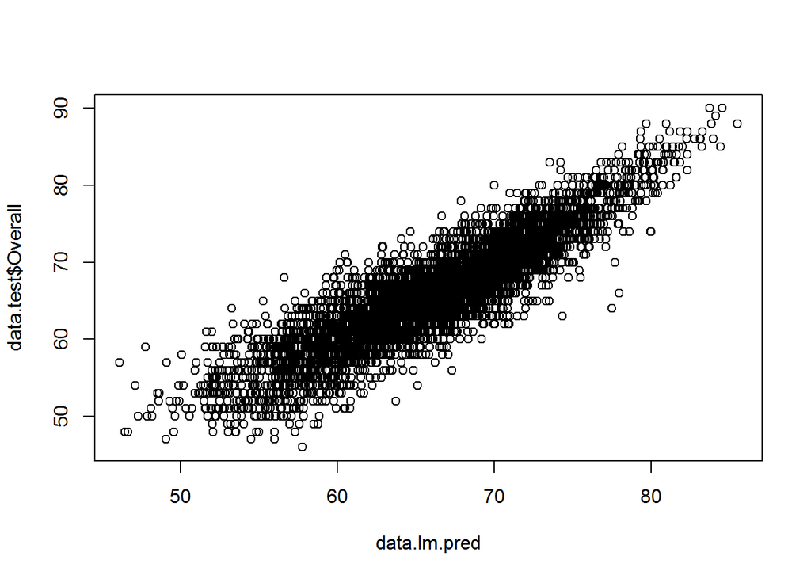

```r
plot(data.lm.pred, data.test$Overall)
```

```r
summary(lm(Overall ~ ., data = data.train))
```

Ramsey Reset Test

```r
resettest(lm(Overall ~ ., data = data.train))
```

```r
res2 <- rcorr(as.matrix(data[, -2]))
res2$P
```

Removing the highly correlated variables (Strength and Dribbling)

```r
data <- data[,-8]
data <- data[,-20]
```

We take the log of the target variable ‘Overall’

We create the correlation matrix again, but decide not to remove any of the variables.

```r
res2 <- rcorr(as.matrix(data[, -2]))
res2$P
```

We Plot the correlations between the target variable and all explanatory variables to see if any of the relationships are logarithmic.

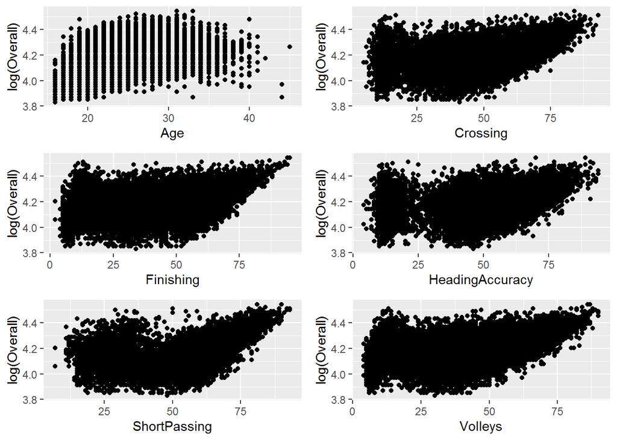

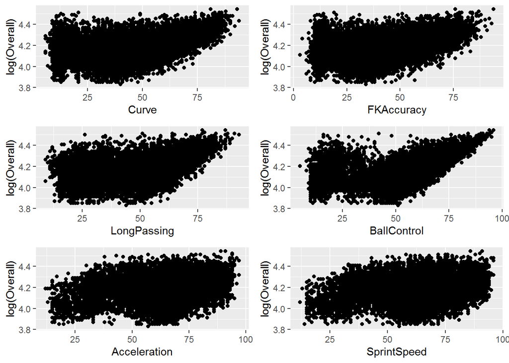

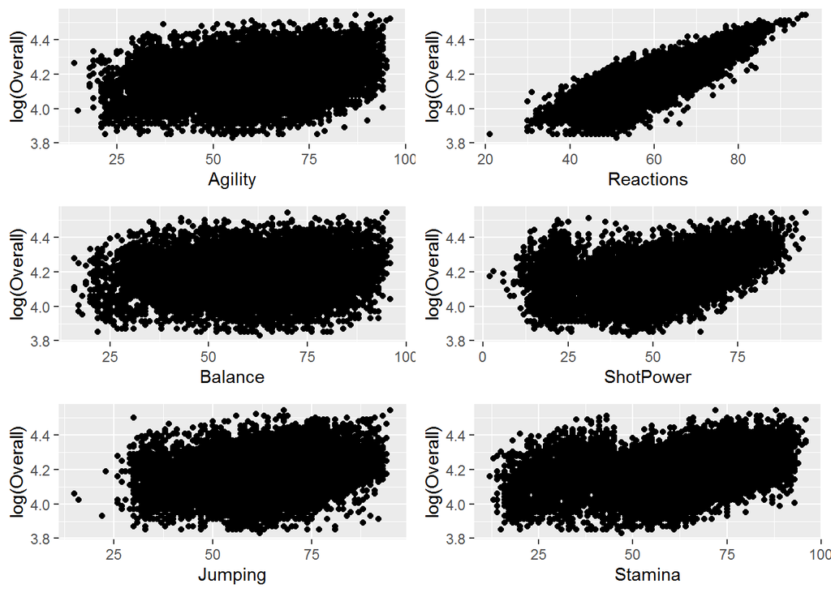

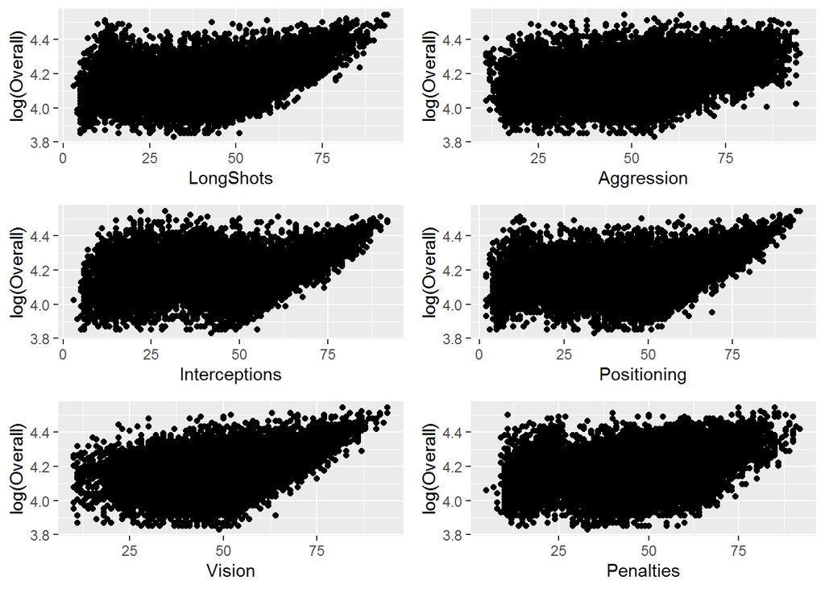

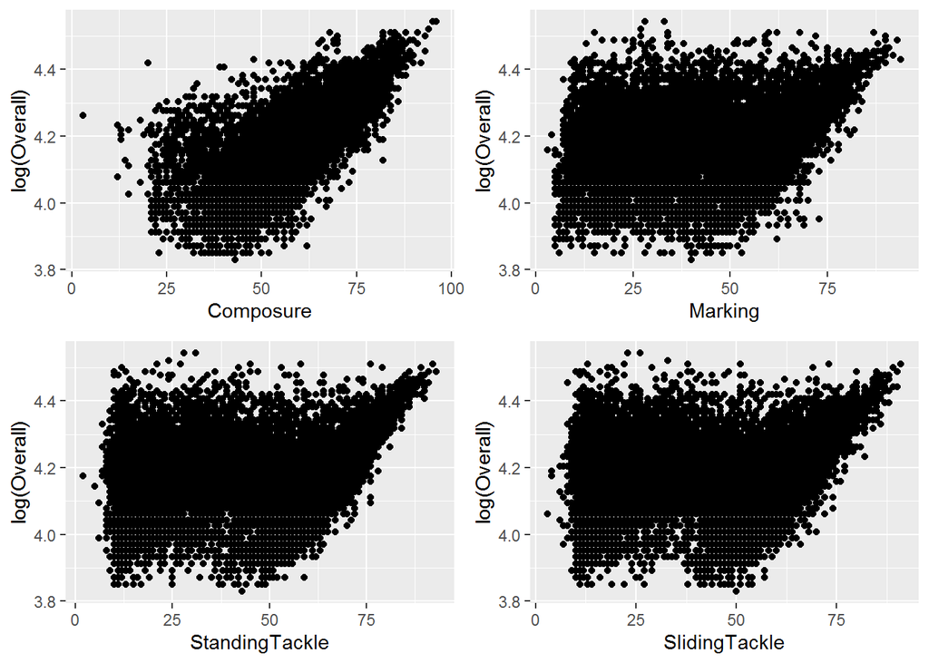

After visually analyzing the correlation plots, we decide to take the log of some explanatory variables.

Next, we estimate the new model.

```r
model2 <-lm(log(Overall) ~  Age + log(Crossing)+ log(Finishing)+ log(HeadingAccuracy)+ log(ShortPassing)+ log(Volleys)+ log(Curve)+ log(FKAccuracy)+ log(LongPassing)+
     log(BallControl)+Acceleration+SprintSpeed+Agility+Reactions+Balance+ShotPower+
     Jumping+Stamina+log(LongShots)+Aggression+log(Interceptions)+log(Positioning)+ log(Vision)+ Penalties+
     Composure+Marking+StandingTackle+ SlidingTackle, data = data.train)

model2
```

```
##
## Call:
## lm(formula = log(Overall) ~ Age + log(Crossing) + log(Finishing) +
##     log(HeadingAccuracy) + log(ShortPassing) + log(Volleys) +
##     log(Curve) + log(FKAccuracy) + log(LongPassing) + log(BallControl) +
##     Acceleration + SprintSpeed + Agility + Reactions + Balance +
##     ShotPower + Jumping + Stamina + log(LongShots) + Aggression +
##     log(Interceptions) + log(Positioning) + log(Vision) + Penalties +
##     Composure + Marking + StandingTackle + SlidingTackle, data = data.train)
##
## Coefficients:
##          (Intercept)                   Age         log(Crossing)
##            3.5706086             0.0020407            -0.0032169
##       log(Finishing)  log(HeadingAccuracy)     log(ShortPassing)
##           -0.0063263            -0.0215858             0.0314838
##         log(Volleys)            log(Curve)       log(FKAccuracy)
##           -0.0029224            -0.0038479            -0.0101545
##     log(LongPassing)      log(BallControl)          Acceleration
##            0.0049247             0.0239338             0.0005639
##          SprintSpeed               Agility             Reactions
##            0.0005616             0.0001141             0.0068255
##              Balance             ShotPower               Jumping
##           -0.0009683             0.0008615             0.0003527
##              Stamina        log(LongShots)            Aggression
##            0.0002514            -0.0071004            -0.0001124
##   log(Interceptions)      log(Positioning)           log(Vision)
##           -0.0122871            -0.0406980             0.0097981
##            Penalties             Composure               Marking
##            0.0002227             0.0024465             0.0003394
##       StandingTackle         SlidingTackle
##            0.0004620            -0.0004442
```

```r
resettest(lm(log(Overall) ~ Age + log(Crossing)+ log(Finishing)+ log(HeadingAccuracy)+ log(ShortPassing)+ log(Volleys)+ log(Curve)+ log(FKAccuracy)+ log(LongPassing)+
     log(BallControl)+Acceleration+SprintSpeed+Agility+Reactions+Balance+ShotPower+
     Jumping+Stamina+log(LongShots)+Aggression+log(Interceptions)+log(Positioning)+ log(Vision)+ Penalties+
     Composure+Marking+StandingTackle+ SlidingTackle, data = data.train))
```

```
##
##  RESET test
##
## data:  lm(log(Overall) ~ Age + log(Crossing) + log(Finishing) + log(HeadingAccuracy) +     log(ShortPassing) + log(Volleys) + log(Curve) + log(FKAccuracy) +     log(LongPassing) + log(BallControl) + Acceleration + SprintSpeed +     Agility + Reactions + Balance + ShotPower + Jumping + Stamina +  …
## RESET = 6.4941, df1 = 2, df2 = 12662, p-value = 0.001517
```

```r
summary(model2)
```

```
##
## Call:
## lm(formula = log(Overall) ~ Age + log(Crossing) + log(Finishing) +
##     log(HeadingAccuracy) + log(ShortPassing) + log(Volleys) +
##     log(Curve) + log(FKAccuracy) + log(LongPassing) + log(BallControl) +
##     Acceleration + SprintSpeed + Agility + Reactions + Balance +
##     ShotPower + Jumping + Stamina + log(LongShots) + Aggression +
##     log(Interceptions) + log(Positioning) + log(Vision) + Penalties +
##     Composure + Marking + StandingTackle + SlidingTackle, data = data.train)
##
## Residuals:
##      Min       1Q   Median       3Q      Max
## -0.26521 -0.02861  0.00170  0.03025  0.21087
##
## Coefficients:
##                        Estimate Std. Error t value Pr(>|t|)
## (Intercept)           3.571e+00  1.154e-02 309.538  < 2e-16 ***
## Age                   2.041e-03  1.158e-04  17.620  < 2e-16 ***
## log(Crossing)        -3.217e-03  2.381e-03  -1.351 0.176672
## log(Finishing)       -6.326e-03  2.547e-03  -2.484 0.013000 *
## log(HeadingAccuracy) -2.159e-02  2.154e-03 -10.020  < 2e-16 ***
## log(ShortPassing)     3.148e-02  4.189e-03   7.516 6.04e-14 ***
## log(Volleys)         -2.922e-03  2.322e-03  -1.259 0.208160
## log(Curve)           -3.848e-03  2.541e-03  -1.514 0.129972
## log(FKAccuracy)      -1.015e-02  2.211e-03  -4.593 4.41e-06 ***
## log(LongPassing)      4.925e-03  3.042e-03   1.619 0.105502
## log(BallControl)      2.393e-02  3.695e-03   6.477 9.71e-11 ***
## Acceleration          5.639e-04  8.462e-05   6.664 2.78e-11 ***
## SprintSpeed           5.616e-04  7.840e-05   7.163 8.32e-13 ***
## Agility               1.141e-04  6.290e-05   1.814 0.069732 .
## Reactions             6.826e-03  7.100e-05  96.131  < 2e-16 ***
## Balance              -9.683e-04  5.210e-05 -18.587  < 2e-16 ***
## ShotPower             8.615e-04  6.001e-05  14.356  < 2e-16 ***
## Jumping               3.527e-04  4.352e-05   8.105 5.75e-16 ***
## Stamina               2.514e-04  5.038e-05   4.989 6.14e-07 ***
## log(LongShots)       -7.100e-03  2.507e-03  -2.833 0.004622 **
## Aggression           -1.124e-04  4.734e-05  -2.375 0.017577 *
## log(Interceptions)   -1.229e-02  2.006e-03  -6.126 9.30e-10 ***
## log(Positioning)     -4.070e-02  2.349e-03 -17.326  < 2e-16 ***
## log(Vision)           9.798e-03  2.422e-03   4.046 5.25e-05 ***
## Penalties             2.227e-04  5.822e-05   3.825 0.000132 ***
## Composure             2.447e-03  6.570e-05  37.237  < 2e-16 ***
## Marking               3.394e-04  5.352e-05   6.341 2.37e-10 ***
## StandingTackle        4.620e-04  1.015e-04   4.554 5.32e-06 ***
## SlidingTackle        -4.442e-04  9.433e-05  -4.708 2.52e-06 ***
## ---
## Signif. codes:  0 '***' 0.001 '**' 0.01 '*' 0.05 '.' 0.1 ' ' 1
##
## Residual standard error: 0.04798 on 12664 degrees of freedom
## Multiple R-squared:  0.794,  Adjusted R-squared:  0.7935
## F-statistic:  1743 on 28 and 12664 DF,  p-value: < 2.2e-16
```

Process of deleting insignificant variables, one at a time.

```r
model2.1 <-lm(log(Overall) ~  Age + log(Crossing)+ log(Finishing)+ log(HeadingAccuracy)+ log(ShortPassing)+  log(Curve)+ log(FKAccuracy)+ log(LongPassing)+
     log(BallControl)+Acceleration+SprintSpeed+Agility+Reactions+Balance+ShotPower+
     Jumping+Stamina+log(LongShots)+Aggression+log(Interceptions)+log(Positioning)+ log(Vision)+ Penalties+
     Composure+Marking+StandingTackle+ SlidingTackle, data = data.train)

summary(model2.1)
```

One more variable removed.

```r
model2.2 <-lm(log(Overall) ~  Age + log(Finishing)+ log(HeadingAccuracy)+ log(ShortPassing)+  log(Curve)+ log(FKAccuracy)+ log(LongPassing)+
     log(BallControl)+Acceleration+SprintSpeed+Agility+Reactions+Balance+ShotPower+
     Jumping+Stamina+log(LongShots)+Aggression+log(Interceptions)+log(Positioning)+ log(Vision)+ Penalties+
     Composure+Marking+StandingTackle+ SlidingTackle, data = data.train)

summary(model2.2)
```

The initial model

```r
summary(model0)
```

```
##
## Call:
## lm(formula = Overall ~ Age + Crossing + Finishing + HeadingAccuracy +
##     ShortPassing + Volleys + Curve + FKAccuracy + LongPassing +
##     BallControl + Acceleration + SprintSpeed + Agility + Reactions +
##     Balance + ShotPower + Jumping + Stamina + log(LongShots) +
##     Aggression + Interceptions + Positioning + Vision + Penalties +
##     Composure + Marking + StandingTackle + SlidingTackle, data = data.train)
##
## Residuals:
##      Min       1Q   Median       3Q      Max
## -16.1941  -1.9677   0.0436   1.9693  13.2255
##
## Coefficients:
##                  Estimate Std. Error t value Pr(>|t|)
## (Intercept)     29.063013   0.410012  70.883  < 2e-16 ***
## Age              0.113095   0.007610  14.861  < 2e-16 ***
## Crossing         0.013584   0.003679   3.692 0.000223 ***
## Finishing        0.024621   0.004601   5.352 8.87e-08 ***
## HeadingAccuracy -0.007617   0.003423  -2.225 0.026087 *
## ShortPassing     0.051270   0.006654   7.705 1.40e-14 ***
## Volleys          0.001066   0.004021   0.265 0.791016
## Curve            0.009060   0.004000   2.265 0.023539 *
## FKAccuracy      -0.002478   0.003499  -0.708 0.478771
## LongPassing      0.006797   0.004877   1.394 0.163455
## BallControl      0.059610   0.006258   9.525  < 2e-16 ***
## Acceleration     0.027868   0.005484   5.082 3.79e-07 ***
## SprintSpeed      0.029040   0.005091   5.704 1.20e-08 ***
## Agility         -0.005876   0.004094  -1.435 0.151276
## Reactions        0.465421   0.004631 100.504  < 2e-16 ***
## Balance         -0.068243   0.003404 -20.050  < 2e-16 ***
## ShotPower        0.047544   0.003991  11.914  < 2e-16 ***
## Jumping          0.032760   0.002860  11.455  < 2e-16 ***
## Stamina          0.004787   0.003287   1.456 0.145282
## log(LongShots)  -2.879995   0.141795 -20.311  < 2e-16 ***
## Aggression      -0.012215   0.003080  -3.966 7.34e-05 ***
## Interceptions   -0.009474   0.004453  -2.128 0.033373 *
## Positioning     -0.079616   0.004257 -18.703  < 2e-16 ***
## Vision           0.027657   0.003972   6.963 3.48e-12 ***
## Penalties       -0.016304   0.003825  -4.263 2.03e-05 ***
## Composure        0.144661   0.004348  33.270  < 2e-16 ***
## Marking          0.014049   0.003517   3.994 6.52e-05 ***
## StandingTackle   0.008358   0.006669   1.253 0.210124
## SlidingTackle   -0.032156   0.006205  -5.182 2.23e-07 ***
## ---
## Signif. codes:  0 '***' 0.001 '**' 0.01 '*' 0.05 '.' 0.1 ' ' 1
##
## Residual standard error: 3.109 on 12664 degrees of freedom
## Multiple R-squared:  0.7989, Adjusted R-squared:  0.7985
## F-statistic:  1797 on 28 and 12664 DF,  p-value: < 2.2e-16
```

```r
dataPredict0 <- predict(model0, data.test)
mean((dataPredict0 - data.test$Overall) ^ 2)
```

```
## [1] 9.417986
```

Our final improved model

```r
summary(model3)
```

```
##
## Call:
## lm(formula = log(Overall) ~ Age + log(Finishing) + log(HeadingAccuracy) +
##     log(ShortPassing) + log(Curve) + log(FKAccuracy) + log(BallControl) +
##     Acceleration + SprintSpeed + Agility + Reactions + Balance +
##     ShotPower + Jumping + Stamina + log(LongShots) + Aggression +
##     log(Interceptions) + log(Positioning) + log(Vision) + Penalties +
##     Composure + Marking + StandingTackle + SlidingTackle, data = data.train)
##
## Residuals:
##       Min        1Q    Median        3Q       Max
## -0.264979 -0.028596  0.001763  0.030289  0.211163
##
## Coefficients:
##                        Estimate Std. Error t value Pr(>|t|)
## (Intercept)           3.570e+00  1.153e-02 309.714  < 2e-16 ***
## Age                   2.032e-03  1.150e-04  17.675  < 2e-16 ***
## log(Finishing)       -7.051e-03  2.476e-03  -2.848 0.004408 **
## log(HeadingAccuracy) -2.223e-02  2.127e-03 -10.451  < 2e-16 ***
## log(ShortPassing)     3.473e-02  3.499e-03   9.926  < 2e-16 ***
## log(Curve)           -5.032e-03  2.410e-03  -2.088 0.036842 *
## log(FKAccuracy)      -1.040e-02  2.186e-03  -4.760 1.96e-06 ***
## log(BallControl)      2.352e-02  3.676e-03   6.400 1.61e-10 ***
## Acceleration          5.550e-04  8.447e-05   6.569 5.25e-11 ***
## SprintSpeed           5.517e-04  7.823e-05   7.052 1.86e-12 ***
## Agility               1.139e-04  6.279e-05   1.815 0.069613 .
## Reactions             6.823e-03  7.074e-05  96.452  < 2e-16 ***
## Balance              -9.746e-04  5.199e-05 -18.747  < 2e-16 ***
## ShotPower             8.607e-04  5.961e-05  14.439  < 2e-16 ***
## Jumping               3.573e-04  4.323e-05   8.265  < 2e-16 ***
## Stamina               2.515e-04  5.027e-05   5.002 5.75e-07 ***
## log(LongShots)       -7.453e-03  2.469e-03  -3.019 0.002542 **
## Aggression           -1.099e-04  4.731e-05  -2.322 0.020252 *
## log(Interceptions)   -1.212e-02  1.996e-03  -6.073 1.29e-09 ***
## log(Positioning)     -4.204e-02  2.275e-03 -18.478  < 2e-16 ***
## log(Vision)           1.063e-02  2.353e-03   4.519 6.27e-06 ***
## Penalties             2.117e-04  5.778e-05   3.664 0.000249 ***
## Composure             2.452e-03  6.533e-05  37.540  < 2e-16 ***
## Marking               3.407e-04  5.349e-05   6.369 1.97e-10 ***
## StandingTackle        4.620e-04  1.013e-04   4.559 5.20e-06 ***
## SlidingTackle        -4.414e-04  9.401e-05  -4.695 2.69e-06 ***
## ---
## Signif. codes:  0 '***' 0.001 '**' 0.01 '*' 0.05 '.' 0.1 ' ' 1
##
## Residual standard error: 0.04799 on 12667 degrees of freedom
## Multiple R-squared:  0.7939, Adjusted R-squared:  0.7935
## F-statistic:  1952 on 25 and 12667 DF,  p-value: < 2.2e-16
```

```r
dataPredict3 <- predict(model3, data.test)

dataPredict3 <- exp(dataPredict3)
mean((dataPredict3 - data.test$Overall) ^ 2)
```

```
## [1] 9.383316
```